# Project_MAA

House pricing Model

Allahverdili Minaya, Aliev Aziz, Ibadova Afet

06/15/2023

# Preparing Libraries

```r
#install libraries
#install.packages("beanplot")
#install.packages("summarytools")
#install.packages("ggplot2")
#install.packages("tidyr")
#install.packages("gridExtra")
#install.packages("scales")
#install.packages("zoo")
#install.packages("dplyr")
#install.packages("gbm")
#install.packages("glmnet")
#install.packages("xgboost")
#install.packages("e1071")
#install.packages("caret")
#install.packages("rpart")
#install.packages("ada")

##Import libraries
library(beanplot)
library(summarytools)
library(ggplot2)
library(tidyr)
library(gridExtra)
library(scales)
library(zoo)
library(dplyr)
library(gbm)
library(glmnet)
library(xgboost)
library(e1071)
library(caret)
library(rpart)
library(randomForest)
```

# Load Dataset

```r
getwd()
```

```
## [1] "C:/Users/Afat/Documents/GitHub/RRGroupProjectMAA"
```

```r
train <- read.csv("train.csv", h=T)
test <- read.csv("test.csv", h=T)
row.names(train) <- train$Id
train$Id <- NULL
row.names(test) <- test$Id
test$Id <- NULL
```

# Data Exploration and Preprocessing

## 1. Investigate TARGET value distribution

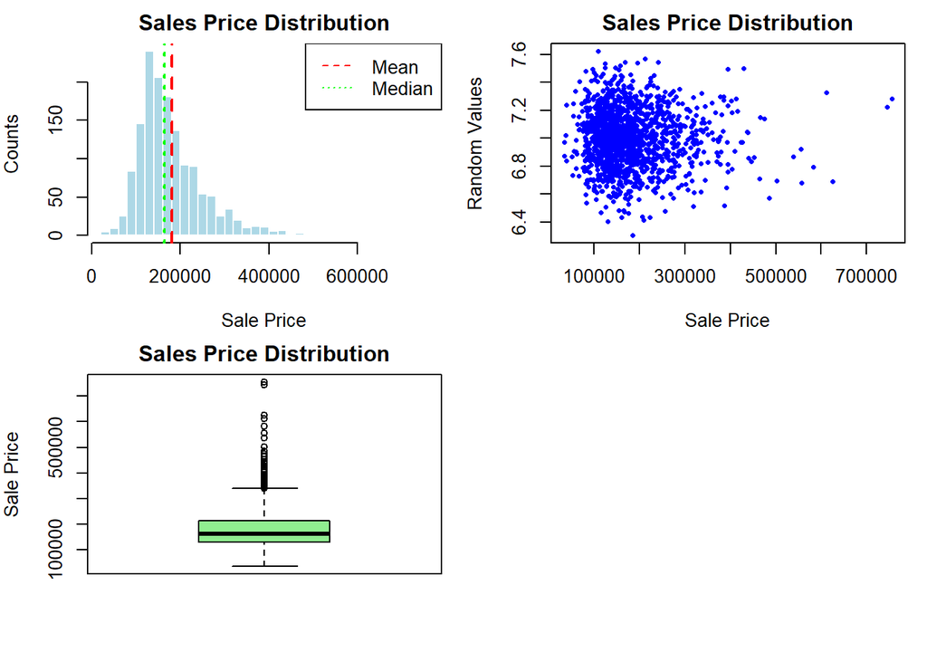

```r
par(mfrow = c(2, 2))
par(mar = c(4, 4, 2, 1)) # Adjusting the margins for better visualization

# Subplot 1
hist(train$SalePrice, breaks = 50, main = "Sales Price Distribution", xlab = "Sale Price",
     ylab = "Counts", col = "lightblue", border = "white")
abline(v = mean(train$SalePrice), lty = 2, col = "red", lwd = 2)
abline(v = median(train$SalePrice), lty = 3, col = "green", lwd = 2)
legend("topright", legend = c("Mean", "Median"), lty = c(2, 3), col = c("red", "green"))

# Subplot 2
plot(train$SalePrice, rnorm(nrow(train), mean = 7, sd = 0.2), main = "Sales Price Distribution",
     xlab = "Sale Price", ylab = "Random Values", pch = 16, col = "blue", cex = 0.6)

# Subplot 3
boxplot(train$SalePrice, main = "Sales Price Distribution", ylab = "Sale Price",
        col = "lightgreen")
```

**Note:** Target is is continuous, and the distribution is skewed to the right. Mostly house price ranges from 100,000 to 200,000.

## 2. Investigate Data Types

```r
str(train)
```

```
## 'data.frame':    1460 obs. of  80 variables:
##  $ MSSubClass   : int  60 20 60 70 60 50 20 60 50 190 ...
##  $ MSZoning     : chr  "RL" "RL" "RL" "RL" ...
##  $ LotFrontage  : int  65 80 68 60 84 85 75 NA 51 50 ...
##  $ LotArea      : int  8450 9600 11250 9550 14260 14115 10084 10382 6120 7420 ...
##  $ Street       : chr  "Pave" "Pave" "Pave" "Pave" ...
##  $ Alley        : chr  NA NA NA NA ...
##  $ LotShape     : chr  "Reg" "Reg" "IR1" "IR1" ...
##  $ LandContour  : chr  "Lvl" "Lvl" "Lvl" "Lvl" ...
##  $ Utilities    : chr  "AllPub" "AllPub" "AllPub" "AllPub" ...
##  $ LotConfig    : chr  "Inside" "FR2" "Inside" "Corner" ...
##  $ LandSlope    : chr  "Gtl" "Gtl" "Gtl" "Gtl" ...
##  $ Neighborhood : chr  "CollgCr" "Veenker" "CollgCr" "Crawfor" ...
##  $ Condition1   : chr  "Norm" "Feedr" "Norm" "Norm" ...
##  $ Condition2   : chr  "Norm" "Norm" "Norm" "Norm" ...
```

[output cut: 66 more lines]

- Some variables, such as **YearBuilt, YearRemodAdd, GarageYrBlt, YrSold, MoSold** are numeric variables, which is related to the year.
- Some variables have a lot of null value, it can be cleaned.

### 2.1. Explore the categorical variables

```r
cat_vars <- names(train)[sapply(train, is.character)]
cat_vars
```

```
##  [1] "MSZoning"      "Street"        "Alley"         "LotShape"
##  [5] "LandContour"   "Utilities"     "LotConfig"     "LandSlope"
##  [9] "Neighborhood"  "Condition1"    "Condition2"    "BldgType"
## [13] "HouseStyle"    "RoofStyle"     "RoofMatl"      "Exterior1st"
## [17] "Exterior2nd"   "MasVnrType"    "ExterQual"     "ExterCond"
## [21] "Foundation"    "BsmtQual"      "BsmtCond"      "BsmtExposure"
## [25] "BsmtFinType1"  "BsmtFinType2"  "Heating"       "HeatingQC"
## [29] "CentralAir"    "Electrical"    "KitchenQual"   "Functional"
## [33] "FireplaceQu"   "GarageType"    "GarageFinish"  "GarageQual"
## [37] "GarageCond"    "PavedDrive"    "PoolQC"        "Fence"
## [41] "MiscFeature"   "SaleType"      "SaleCondition"
```

**MSSubClass** is also categorical by definition, despite its numeric values. MSSubClass should be added to the list of categorical variables.

```r
cat_vars <- c(cat_vars, "MSSubClass")
length(cat_vars)
```

```
## [1] 44
```

```r
train[cat_vars] <- lapply(train[cat_vars], as.character)
t(sapply(train[cat_vars], summary))
```

```
##               Length Class       Mode
## MSZoning      "1460" "character" "character"
## Street        "1460" "character" "character"
## Alley         "1460" "character" "character"
## LotShape      "1460" "character" "character"
## LandContour   "1460" "character" "character"
## Utilities     "1460" "character" "character"
## LotConfig     "1460" "character" "character"
## LandSlope     "1460" "character" "character"
## Neighborhood  "1460" "character" "character"
## Condition1    "1460" "character" "character"
## Condition2    "1460" "character" "character"
## BldgType      "1460" "character" "character"
## HouseStyle    "1460" "character" "character"
## RoofStyle     "1460" "character" "character"
## RoofMatl      "1460" "character" "character"
## Exterior1st   "1460" "character" "character"
## Exterior2nd   "1460" "character" "character"
## MasVnrType    "1460" "character" "character"
## ExterQual     "1460" "character" "character"
## ExterCond     "1460" "character" "character"
## Foundation    "1460" "character" "character"
## BsmtQual      "1460" "character" "character"
## BsmtCond      "1460" "character" "character"
## BsmtExposure  "1460" "character" "character"
## BsmtFinType1  "1460" "character" "character"
## BsmtFinType2  "1460" "character" "character"
## Heating       "1460" "character" "character"
## HeatingQC     "1460" "character" "character"
## CentralAir    "1460" "character" "character"
## Electrical    "1460" "character" "character"
## KitchenQual   "1460" "character" "character"
## Functional    "1460" "character" "character"
## FireplaceQu   "1460" "character" "character"
## GarageType    "1460" "character" "character"
## GarageFinish  "1460" "character" "character"
## GarageQual    "1460" "character" "character"
## GarageCond    "1460" "character" "character"
## PavedDrive    "1460" "character" "character"
## PoolQC        "1460" "character" "character"
## Fence         "1460" "character" "character"
## MiscFeature   "1460" "character" "character"
## SaleType      "1460" "character" "character"
## SaleCondition "1460" "character" "character"
## MSSubClass    "1460" "character" "character"
```

**Summary for categorical variables:**

```r
dfSummary(train[cat_vars])
```

```
## Data Frame Summary
## train
## Dimensions: 1460 x 44
## Duplicates: 21
##
## -----------------------------------------------------------------------------------------------------
## No   Variable        Stats / Values   Freqs (% of Valid)   Graph                 Valid      Missing
## ---- --------------- ---------------- -------------------- --------------------- ---------- ---------
## 1    MSZoning        1. C (all)         10 ( 0.7%)                               1460       0
##      [character]     2. FV              65 ( 4.5%)                               (100.0%)   (0.0%)
##                      3. RH              16 ( 1.1%)
##                      4. RL            1151 (78.8%)         IIIIIIIIIIIIIII
##                      5. RM             218 (14.9%)         II
##
## 2    Street          1. Grvl             6 ( 0.4%)                               1460       0
##      [character]     2. Pave          1454 (99.6%)         IIIIIIIIIIIIIIIIIII   (100.0%)   (0.0%)
##
## 3    Alley           1. Grvl          50 (54.9%)           IIIIIIIIII            91         1369
##      [character]     2. Pave          41 (45.1%)           IIIIIIIII             (6.2%)     (93.8%)
##
## 4    LotShape        1. IR1           484 (33.2%)          IIIIII                1460       0
##      [character]     2. IR2            41 ( 2.8%)                                (100.0%)   (0.0%)
##                      3. IR3            10 ( 0.7%)
##                      4. Reg           925 (63.4%)          IIIIIIIIIIII
##
## 5    LandContour     1. Bnk             63 ( 4.3%)                               1460       0
##      [character]     2. HLS             50 ( 3.4%)                               (100.0%)   (0.0%)
##                      3. Low             36 ( 2.5%)
##                      4. Lvl           1311 (89.8%)         IIIIIIIIIIIIIIIII
##
## 6    Utilities       1. AllPub        1459 (99.9%)         IIIIIIIIIIIIIIIIIII   1460       0
##      [character]     2. NoSeWa           1 ( 0.1%)                               (100.0%)   (0.0%)
##
## 7    LotConfig       1. Corner         263 (18.0%)         III                   1460       0
##      [character]     2. CulDSac         94 ( 6.4%)         I                     (100.0%)   (0.0%)
##                      3. FR2             47 ( 3.2%)
##                      4. FR3              4 ( 0.3%)
##                      5. Inside        1052 (72.1%)         IIIIIIIIIIIIII
##
## 8    LandSlope       1. Gtl           1382 (94.7%)         IIIIIIIIIIIIIIIIII    1460       0
```

[output cut: 237 more lines]

```
##                      5. Normal        1198 (82.1%)         IIIIIIIIIIIIIIII
##                      6. Partial        125 ( 8.6%)         I
##
## 44   MSSubClass      1. 20            536 (36.7%)          IIIIIII               1460       0
##      [character]     2. 60            299 (20.5%)          IIII                  (100.0%)   (0.0%)
##                      3. 50            144 ( 9.9%)          I
##                      4. 120            87 ( 6.0%)          I
##                      5. 30             69 ( 4.7%)
##                      6. 160            63 ( 4.3%)
##                      7. 70             60 ( 4.1%)
##                      8. 80             58 ( 4.0%)
##                      9. 90             52 ( 3.6%)
##                      10. 190           30 ( 2.1%)
##                      [ 5 others ]      62 ( 4.2%)
## -----------------------------------------------------------------------------------------------------
```

### 2.2. Explore the continues variables

```r
stat_cont <- summary(train[, sapply(train, is.numeric)])
stat_cont
```

```
##   LotFrontage        LotArea        OverallQual      OverallCond
##  Min.   : 21.00   Min.   :  1300   Min.   : 1.000   Min.   :1.000
##  1st Qu.: 59.00   1st Qu.:  7554   1st Qu.: 5.000   1st Qu.:5.000
##  Median : 69.00   Median :  9478   Median : 6.000   Median :5.000
##  Mean   : 70.05   Mean   : 10517   Mean   : 6.099   Mean   :5.575
##  3rd Qu.: 80.00   3rd Qu.: 11602   3rd Qu.: 7.000   3rd Qu.:6.000
##  Max.   :313.00   Max.   :215245   Max.   :10.000   Max.   :9.000
##  NA's   :259
##    YearBuilt     YearRemodAdd    MasVnrArea       BsmtFinSF1
##  Min.   :1872   Min.   :1950   Min.   :   0.0   Min.   :   0.0
##  1st Qu.:1954   1st Qu.:1967   1st Qu.:   0.0   1st Qu.:   0.0
##  Median :1973   Median :1994   Median :   0.0   Median : 383.5
##  Mean   :1971   Mean   :1985   Mean   : 103.7   Mean   : 443.6
##  3rd Qu.:2000   3rd Qu.:2004   3rd Qu.: 166.0   3rd Qu.: 712.2
##  Max.   :2010   Max.   :2010   Max.   :1600.0   Max.   :5644.0
##                                NA's   :8
##    BsmtFinSF2        BsmtUnfSF       TotalBsmtSF       X1stFlrSF
##  Min.   :   0.00   Min.   :   0.0   Min.   :   0.0   Min.   : 334
##  1st Qu.:   0.00   1st Qu.: 223.0   1st Qu.: 795.8   1st Qu.: 882
##  Median :   0.00   Median : 477.5   Median : 991.5   Median :1087
##  Mean   :  46.55   Mean   : 567.2   Mean   :1057.4   Mean   :1163
##  3rd Qu.:   0.00   3rd Qu.: 808.0   3rd Qu.:1298.2   3rd Qu.:1391
##  Max.   :1474.00   Max.   :2336.0   Max.   :6110.0   Max.   :4692
##
##    X2ndFlrSF     LowQualFinSF       GrLivArea     BsmtFullBath
##  Min.   :   0   Min.   :  0.000   Min.   : 334   Min.   :0.0000
##  1st Qu.:   0   1st Qu.:  0.000   1st Qu.:1130   1st Qu.:0.0000
##  Median :   0   Median :  0.000   Median :1464   Median :0.0000
##  Mean   : 347   Mean   :  5.845   Mean   :1515   Mean   :0.4253
##  3rd Qu.: 728   3rd Qu.:  0.000   3rd Qu.:1777   3rd Qu.:1.0000
##  Max.   :2065   Max.   :572.000   Max.   :5642   Max.   :3.0000
##
##   BsmtHalfBath        FullBath        HalfBath       BedroomAbvGr
##  Min.   :0.00000   Min.   :0.000   Min.   :0.0000   Min.   :0.000
##  1st Qu.:0.00000   1st Qu.:1.000   1st Qu.:0.0000   1st Qu.:2.000
##  Median :0.00000   Median :2.000   Median :0.0000   Median :3.000
##  Mean   :0.05753   Mean   :1.565   Mean   :0.3829   Mean   :2.866
##  3rd Qu.:0.00000   3rd Qu.:2.000   3rd Qu.:1.0000   3rd Qu.:3.000
##  Max.   :2.00000   Max.   :3.000   Max.   :2.0000   Max.   :8.000
##
```

[output cut: 17 more lines]

```
##  Min.   :  0.00   Min.   :  0.00   Min.   :  0.00   Min.   :  0.000
##  1st Qu.:  0.00   1st Qu.:  0.00   1st Qu.:  0.00   1st Qu.:  0.000
##  Median :  0.00   Median :  0.00   Median :  0.00   Median :  0.000
##  Mean   : 21.95   Mean   :  3.41   Mean   : 15.06   Mean   :  2.759
##  3rd Qu.:  0.00   3rd Qu.:  0.00   3rd Qu.:  0.00   3rd Qu.:  0.000
##  Max.   :552.00   Max.   :508.00   Max.   :480.00   Max.   :738.000
##
##     MiscVal             MoSold           YrSold       SalePrice
##  Min.   :    0.00   Min.   : 1.000   Min.   :2006   Min.   : 34900
##  1st Qu.:    0.00   1st Qu.: 5.000   1st Qu.:2007   1st Qu.:129975
##  Median :    0.00   Median : 6.000   Median :2008   Median :163000
##  Mean   :   43.49   Mean   : 6.322   Mean   :2008   Mean   :180921
##  3rd Qu.:    0.00   3rd Qu.: 8.000   3rd Qu.:2009   3rd Qu.:214000
##  Max.   :15500.00   Max.   :12.000   Max.   :2010   Max.   :755000
##
```

```r
tr_cont <- train[, !sapply(train, is.character)]
head(tr_cont)
```

```
##   LotFrontage LotArea OverallQual OverallCond YearBuilt YearRemodAdd MasVnrArea
## 1          65    8450           7           5      2003         2003        196
## 2          80    9600           6           8      1976         1976          0
## 3          68   11250           7           5      2001         2002        162
## 4          60    9550           7           5      1915         1970          0
## 5          84   14260           8           5      2000         2000        350
## 6          85   14115           5           5      1993         1995          0
##   BsmtFinSF1 BsmtFinSF2 BsmtUnfSF TotalBsmtSF X1stFlrSF X2ndFlrSF LowQualFinSF
## 1        706          0       150         856       856       854            0
## 2        978          0       284        1262      1262         0            0
## 3        486          0       434         920       920       866            0
## 4        216          0       540         756       961       756            0
## 5        655          0       490        1145      1145      1053            0
## 6        732          0        64         796       796       566            0
##   GrLivArea BsmtFullBath BsmtHalfBath FullBath HalfBath BedroomAbvGr
```

[output cut: 27 more lines]

**Plotting heatmap for visualizing correlation:**

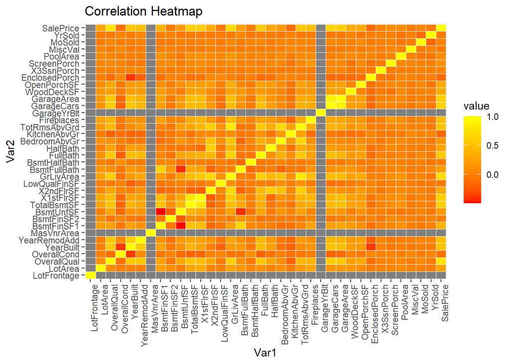

```r
corr <- cor(tr_cont)
melted_corr <- as.data.frame(as.table(corr))
colnames(melted_corr) <- c("Var1", "Var2", "value")



# Increase the plot size
options(repr.plot.width = 30, repr.plot.height = 30)

ggplot(melted_corr, aes(x = Var1, y = Var2, fill = value)) +
  geom_tile(color = "white") +  # Set the tile border color to white
  scale_fill_gradient(low = "red", high = "yellow") +
  labs(title = "Correlation Heatmap") +
  theme(axis.text.x = element_text(angle = 90, hjust = 1),  # Rotate x-axis labels
        panel.grid = element_blank())  # Remove grid lines
```

**Histograms for continues variables:**

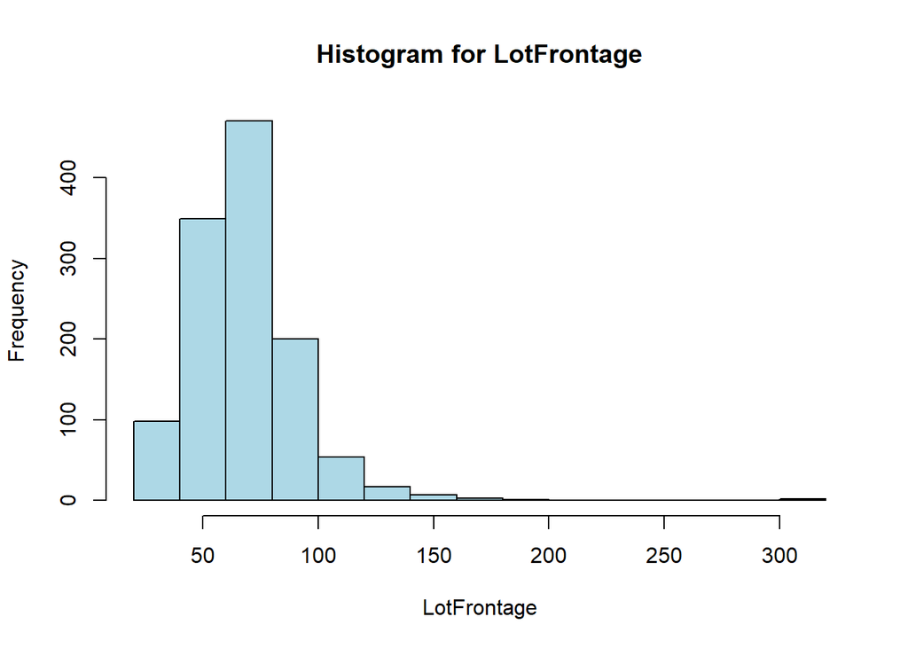

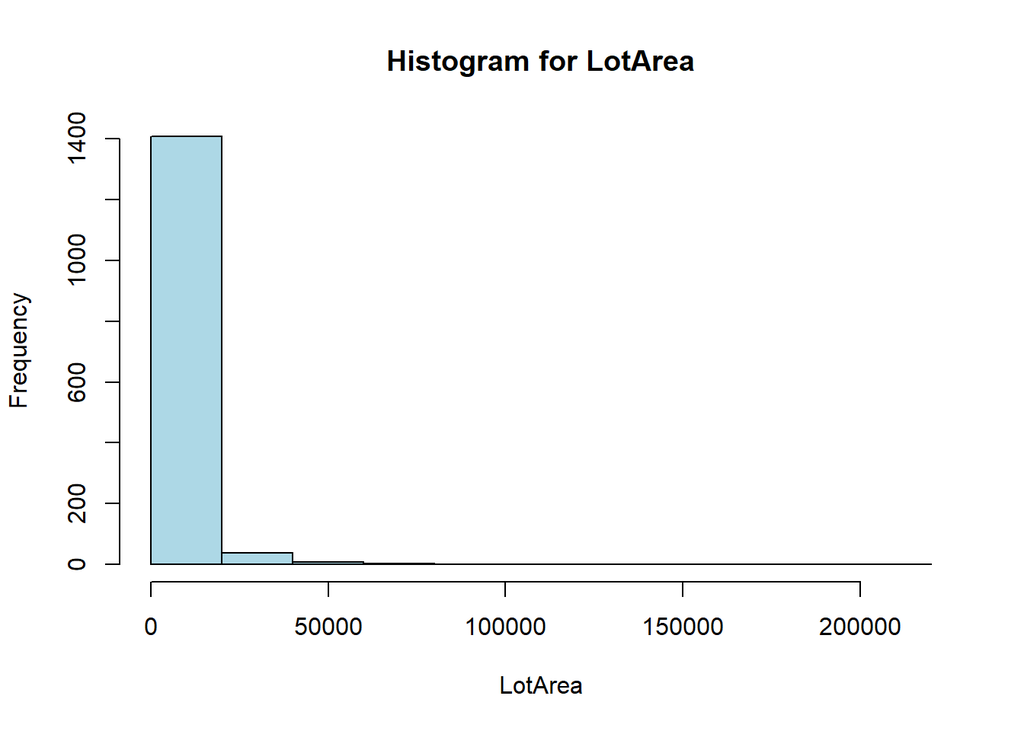

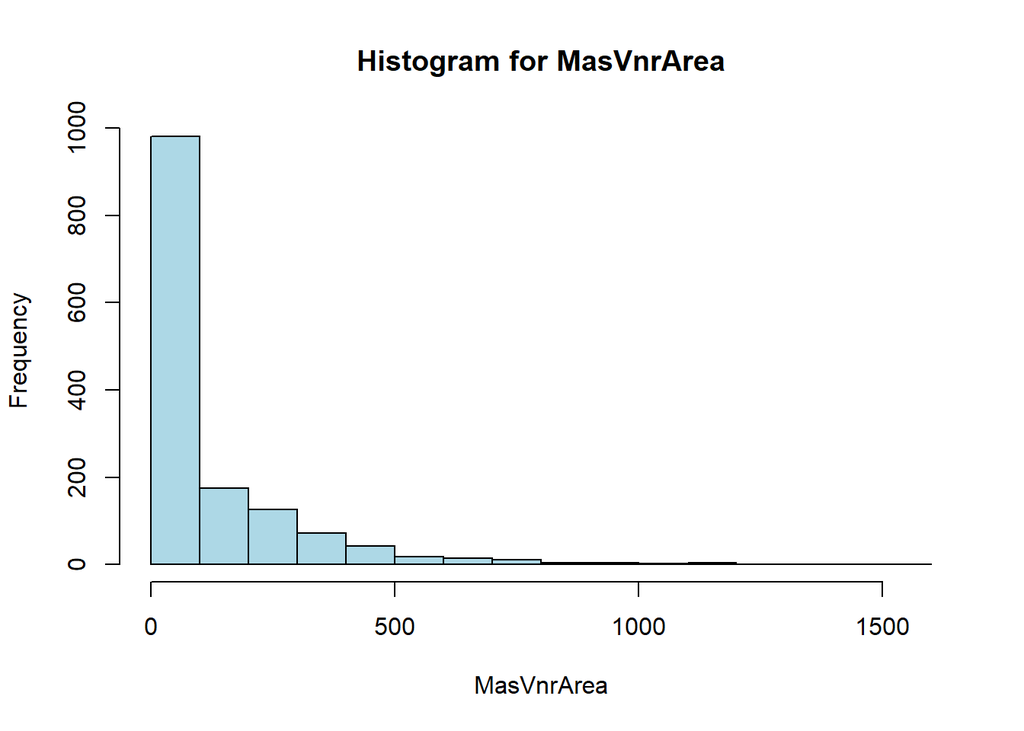

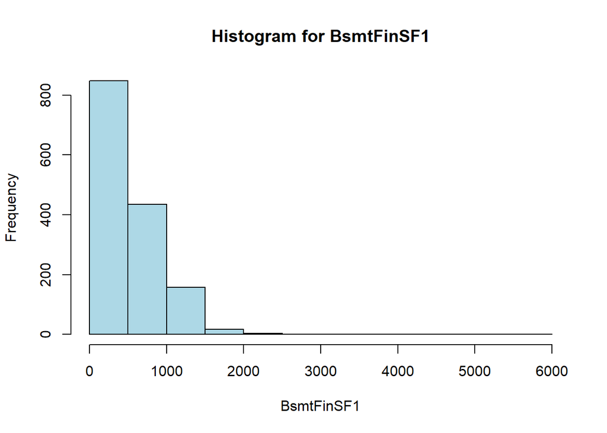

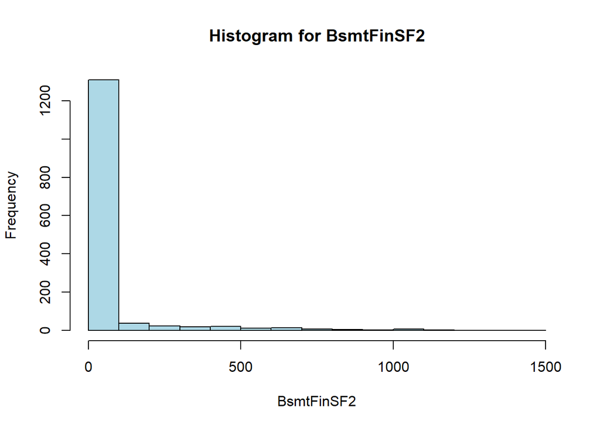

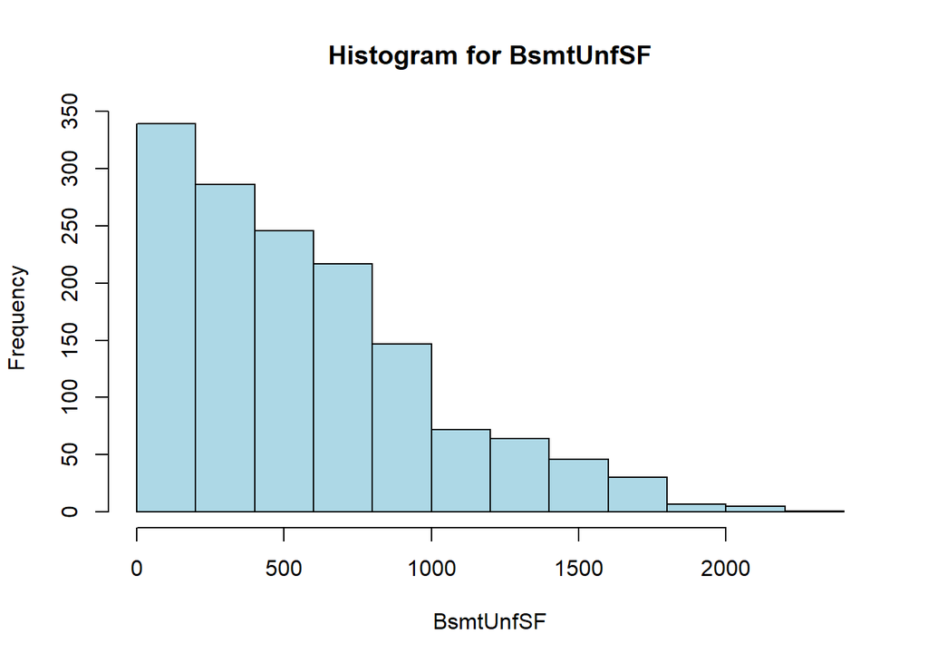

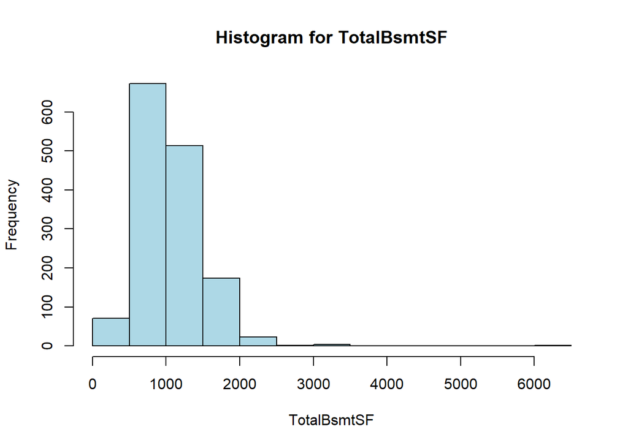

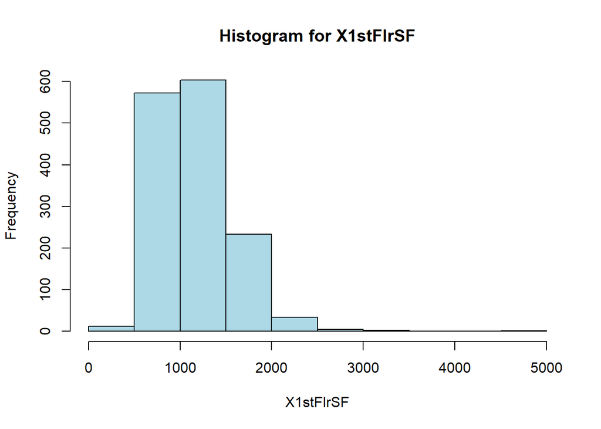

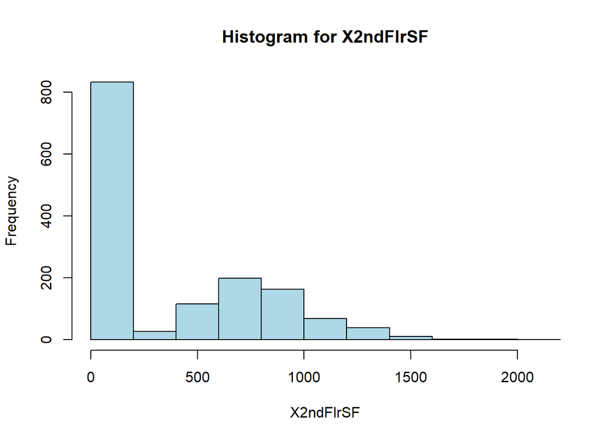

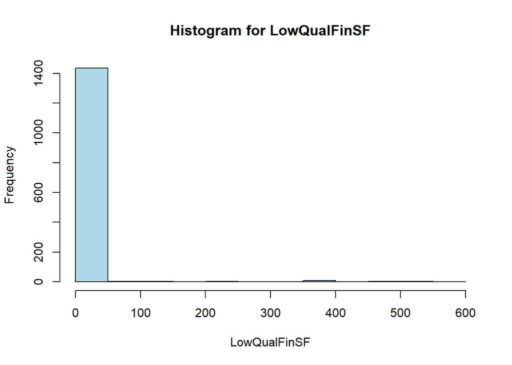

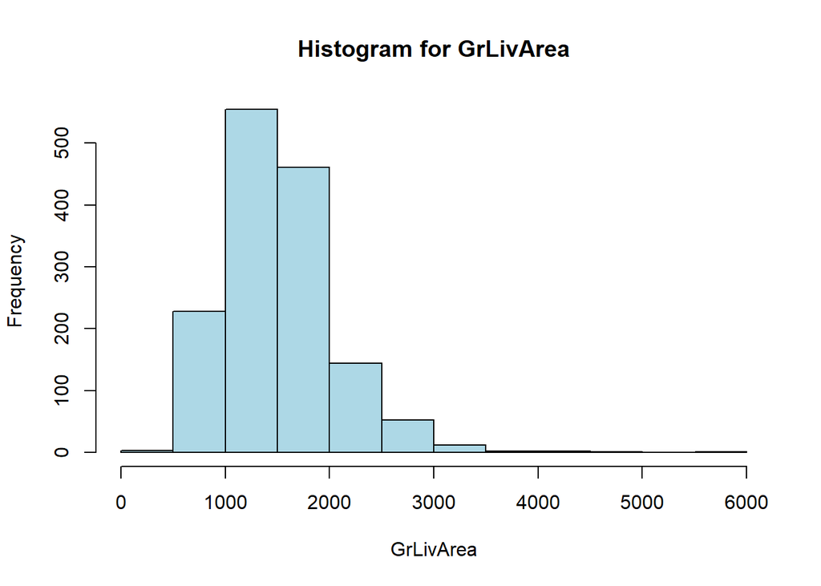

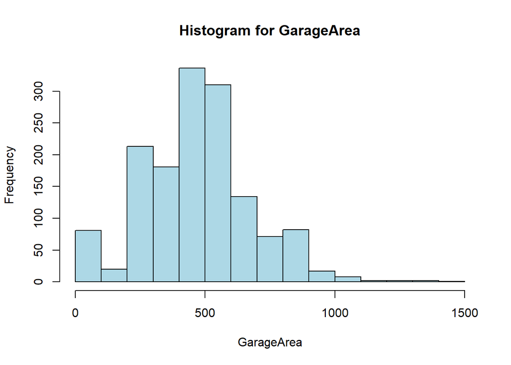

[7 more figures not shown]

```r
# Select continuous features to plot
features <- names(tr_cont)[!(names(tr_cont) %in% c("Id", "OverallQual", "OverallCond", "YearBuilt", "YearRemodAdd",
                                                   "BsmtFullBath", "BsmtHalfBath", "FullBath", "HalfBath",
                                                   "BedroomAbvGr", "KitchenAbvGr", "TotRmsAbvGrd", "Fireplaces",
                                                   "GarageYrBlt", "GarageCars", "MoSold", "YrSold", "SalePrice"))]

for (i in 1:length(features)) {
  hist(tr_cont[[features[i]]], main = paste("Histogram for", features[i]), xlab = features[i], col ="lightblue")
}
```

### 2.3. Missing values

Check the missing values for train dataset:

```r
missing_values <- colSums(is.na(train))

missing_values <- missing_values[order(-missing_values)]
```

Display the top 20 variables with the highest number of missing values

```r
head(missing_values, 20)
```

```
##       PoolQC  MiscFeature        Alley        Fence  FireplaceQu  LotFrontage
##         1453         1406         1369         1179          690          259
##   GarageType  GarageYrBlt GarageFinish   GarageQual   GarageCond BsmtExposure
##           81           81           81           81           81           38
## BsmtFinType2     BsmtQual     BsmtCond BsmtFinType1   MasVnrType   MasVnrArea
##           38           37           37           37            8            8
##   Electrical   MSSubClass
##            1            0
```

Check the missing values for test dataset:

```r
missing_values <- colSums(is.na(test))

missing_values <- missing_values[order(-missing_values)]
```

Display the top 35 variables with the highest number of missing values

```r
head(missing_values, 35)
```

```
##       PoolQC  MiscFeature        Alley        Fence  FireplaceQu  LotFrontage
##         1456         1408         1352         1169          730          227
##  GarageYrBlt GarageFinish   GarageQual   GarageCond   GarageType     BsmtCond
##           78           78           78           78           76           45
##     BsmtQual BsmtExposure BsmtFinType1 BsmtFinType2   MasVnrType   MasVnrArea
##           44           44           42           42           16           15
##     MSZoning    Utilities BsmtFullBath BsmtHalfBath   Functional  Exterior1st
##            4            2            2            2            2            1
##  Exterior2nd   BsmtFinSF1   BsmtFinSF2    BsmtUnfSF  TotalBsmtSF  KitchenQual
##            1            1            1            1            1            1
##   GarageCars   GarageArea     SaleType   MSSubClass      LotArea
##            1            1            1            0            0
```

*Note:* For both dataset some variables have a lot missing values: PoolQC, MiscFeature, Alley, Fence, FireplaceQu, LotFrontage

Drop the “PoolQC” column from the train dataset

```r
train <- train[, !(colnames(train) %in% "PoolQC")]
```

Drop the “PoolQC” column from the test dataset:

```r
test <- test[, !(colnames(test) %in% "PoolQC")]
```

**Fill the missing variables for the categorical variables:**

Define the features with missing values:

```r
obj_NA <- c("Alley", "BsmtQual", "BsmtCond", "BsmtExposure", "BsmtFinType1",

"BsmtFinType2", "FireplaceQu", "GarageType", "GarageFinish",

"GarageQual", "GarageCond", "Fence", "MiscFeature")
```

Fill in missing values with “NA” for the specified features in the train dataset

```r
for (i in obj_NA) {

train[, i][is.na(train[, i])] <- "NA"

}
```

Fill in missing values with “NA” for the specified features in the test dataset:

```r
for (i in obj_NA) {

test[, i][is.na(test[, i])] <- "NA"

}
```

Fill in missing values for the MSZoning, MasVnrType, Electrical, KitchenQual, Functional and SaleType:

```r
obj_mode <- c("MSZoning", "MasVnrType", "Electrical", "KitchenQual", "Functional", "SaleType")

train$MSZoning[train$MSZoning == "C (all)"] <- "C"
test$MSZoning[test$MSZoning == "C (all)"] <- "C"
```

```r
for (i in obj_mode) {
  train[[i]][is.na(train[[i]])] <- names(which.max(table(train[[i]])))
  test[[i]][is.na(test[[i]])] <- names(which.max(table(test[[i]])))
}
```

Fill in missing values for the Utilities feature

```r
test$Utilities[is.na(test$Utilities)] <- "NoSeWa"
```

Fill in missing values for the Exterior1st feature

```r
test$Exterior1st[is.na(test$Exterior1st)] <- "ImStucc"
```

Fill in missing values for the Exterior2nd feature

```r
test$Exterior2nd[is.na(test$Exterior2nd)] <- "Other"
```

**Clean continues variables:**

Fill missing variables

Fill in missing values for the LotFrontage and MasVnrArea features

```r
obj_median <- c("LotFrontage", "MasVnrArea")

for (i in obj_median) {
  train[[i]] <- na.aggregate(train[[i]], FUN = median)
  test[[i]] <- na.aggregate(test[[i]], FUN = median)
}
```

Fill in missing values for the BsmtFinSF1, BsmtFinSF2, BsmtUnfSF, TotalBsmtSF, BsmtFullBath, BsmtHalfBath, GarageCars and GarageArea features

```r
Mode <- function(x) {
  ux <- unique(x)
  ux[which.max(tabulate(match(x, ux)))]
}

obj_mode <- c("BsmtFinSF1", "BsmtFinSF2", "BsmtUnfSF", "TotalBsmtSF", "BsmtFullBath", "BsmtHalfBath", "GarageCars", "GarageArea")

for (i in obj_mode) {
  test[[i]] <- replace(test[[i]], is.na(test[[i]]), Mode(test[[i]]))
}
```

Fill in missing values for the GarageYrBlt feature

```r
train$GarageYrBlt <- ifelse(is.na(train$GarageYrBlt), train$YearBuilt, train$GarageYrBlt)
test$GarageYrBlt <- ifelse(is.na(test$GarageYrBlt), test$YearBuilt, test$GarageYrBlt)
```

Converting dtype to ‘int64’:

```r
int_list <- c("LotFrontage", "BsmtFinSF1", "BsmtFinSF2", "BsmtUnfSF", "TotalBsmtSF", "BsmtFullBath", "BsmtHalfBath", "GarageYrBlt", "GarageCars", "GarageArea")

for (i in int_list) {
  train[[i]] <- as.integer(train[[i]])
  test[[i]] <- as.integer(test[[i]])
}
```

check the shape of dataset:

```r
dim(train)
```

```
## [1] 1460   79
```

### 2.4. Feature Selection

#### Correlation Analysis

Filter numeric variables

```r
numeric_vars <- sapply(train, is.numeric)

# Calculate correlation matrix
correlations <- cor(train[, numeric_vars])

# Sort correlations with 'SalePrice'
sorted_correlations <- sort(correlations[,"SalePrice"], decreasing = TRUE)
```

```r
cat("Most Positive Correlations:\n")
```

[output not shown]

```r
print(tail(sorted_correlations, 10))
```

```
##        MoSold    X3SsnPorch    BsmtFinSF2  BsmtHalfBath       MiscVal
##    0.04643225    0.04458367   -0.01137812   -0.01684415   -0.02118958
##  LowQualFinSF        YrSold   OverallCond EnclosedPorch  KitchenAbvGr
##   -0.02560613   -0.02892259   -0.07785589   -0.12857796   -0.13590737
```

```r
cat("\nMost Negative Correlations:\n")
```

[output not shown]

```r
print(head(sorted_correlations, 10))
```

```
##    SalePrice  OverallQual    GrLivArea   GarageCars   GarageArea  TotalBsmtSF
##    1.0000000    0.7909816    0.7086245    0.6404092    0.6234314    0.6135806
##    X1stFlrSF     FullBath TotRmsAbvGrd    YearBuilt
##    0.6058522    0.5606638    0.5337232    0.5228973
```

**Area vs Sale Price**

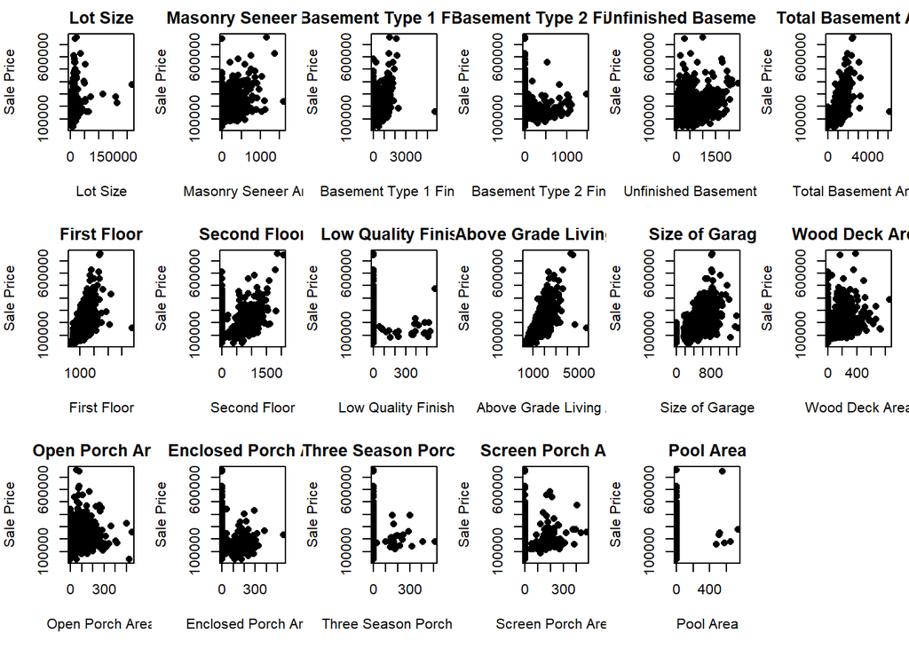

```r
par(mfrow=c(3, 6), mar=c(5, 4, 2, 1)) # Set the layout of subplots

labels <- c("LotArea","MasVnrArea","BsmtFinSF1","BsmtFinSF2",
            "BsmtUnfSF","TotalBsmtSF","X1stFlrSF","X2ndFlrSF",
            "LowQualFinSF","GrLivArea","GarageArea","WoodDeckSF",
            "OpenPorchSF","EnclosedPorch","X3SsnPorch","ScreenPorch","PoolArea")
desc <- c("Lot Size","Masonry Seneer Area","Basement Type 1 Finished",
          "Basement Type 2 Finished","Unfinished Basement Area",
          "Total Basement Area","First Floor","Second Floor",
          "Low Quality Finished","Above Grade Living Area",
          "Size of Garage","Wood Deck Area","Open Porch Area",
          "Enclosed Porch Area","Three Season Porch Area","Screen Porch Area","Pool Area")

for (i in 1:length(labels)) {
  if (i <= 17) {
    plot(train[[labels[i]]], train[["SalePrice"]],
         xlab = desc[i], ylab = "Sale Price",
         main = desc[i], pch = 16)
  }
}
```

**Neighborhood vs Sale Price**

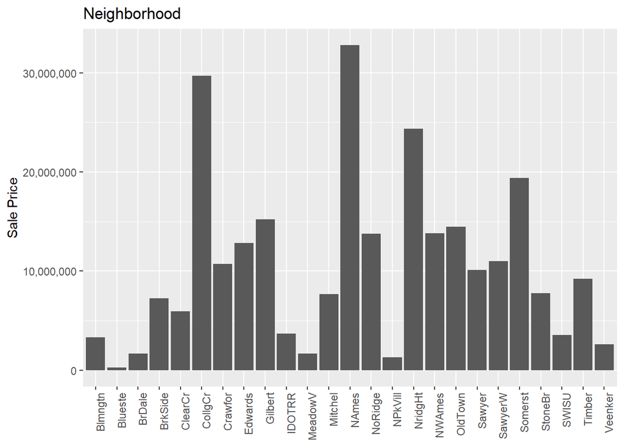

```r
ggplot(train, aes(x = Neighborhood, y = SalePrice)) +
  geom_bar(stat = "identity") +
  labs(x = NULL, y = "Sale Price") +
  ggtitle("Neighborhood") +
  scale_y_continuous(labels = scales::comma) +
  theme(axis.text.x = element_text(angle = 90, hjust = 1))
```

**Building type, House Style**

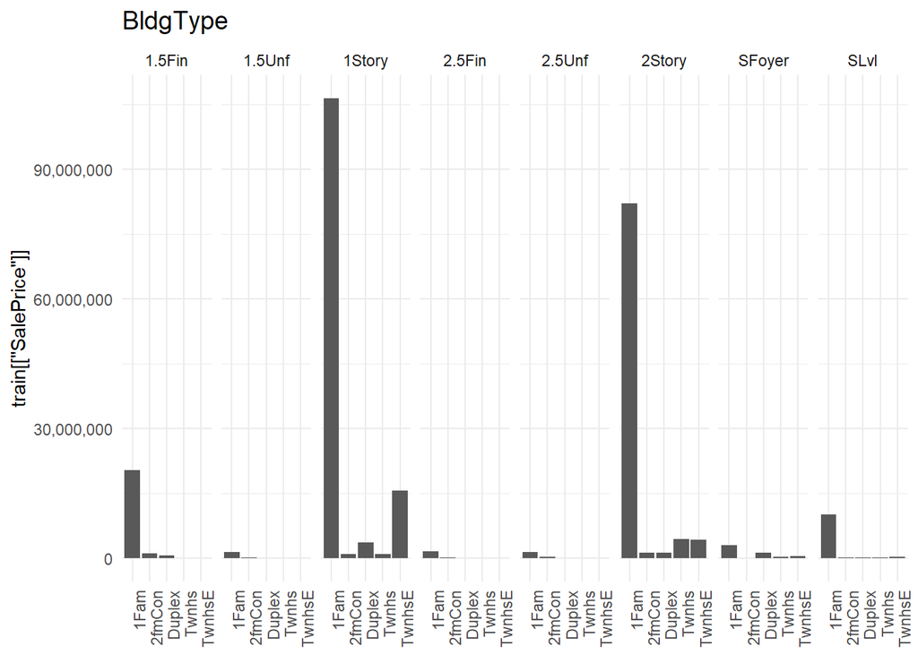

```r
labels <- c("BldgType", "HouseStyle")

plt <- ggplot(train, aes(x = train[[labels[1]]], y = train[["SalePrice"]])) +
  geom_bar(stat = "identity") +
  labs(x = NULL) +
  ggtitle(labels[1])

plt <- plt + facet_wrap(~ train[[labels[2]]], nrow = 1)

plt <- plt + theme_minimal() +
  scale_y_continuous(labels = scales::comma) +
  theme(plot.title = element_text(size = 14),
        axis.text.x = element_text(angle = 90, hjust = 1))

print(plt)
```

**House Quality**

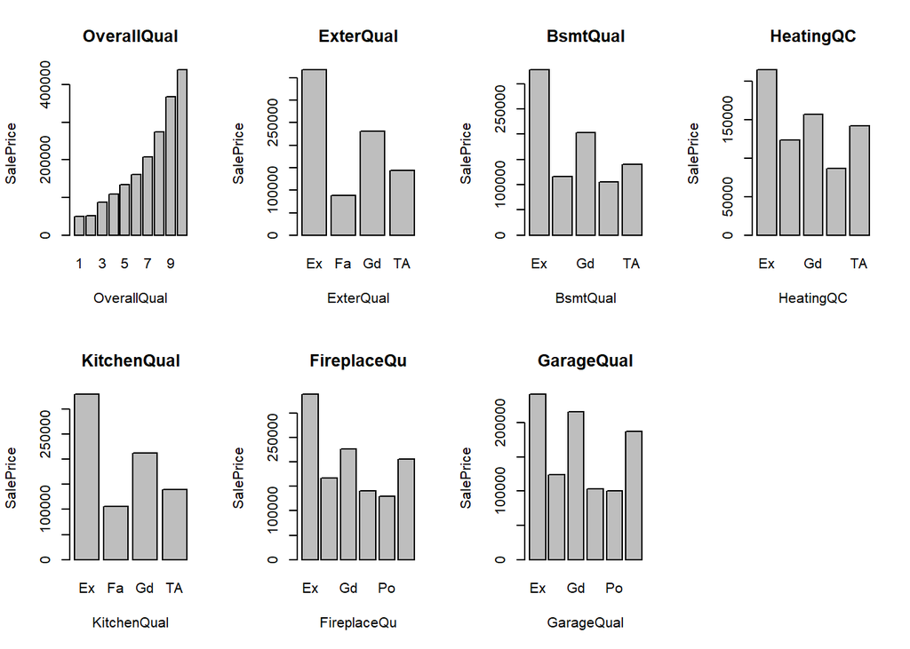

```r
par(mfrow = c(2, 4))
labels <- c("OverallQual", "ExterQual", "BsmtQual", "HeatingQC", "KitchenQual", "FireplaceQu", "GarageQual")
col <- 1

for (i in labels) {
  if (col < 9) {
    plot_col <- col %% 4
    if (plot_col == 0) {
      plot_col <- 4
    }
    plot_row <- ceiling(col / 4)
    plot_index <- (plot_row - 1) * 4 + plot_col

    barplot(tapply(train$SalePrice, train[, i], mean), xlab = i, ylab = "SalePrice")
    title(main = i)
  }

  col <- col + 1
}
```

**Note:** It can be seen that there is positive relation between quality and price. Price increases according to the quality.

**House condition**

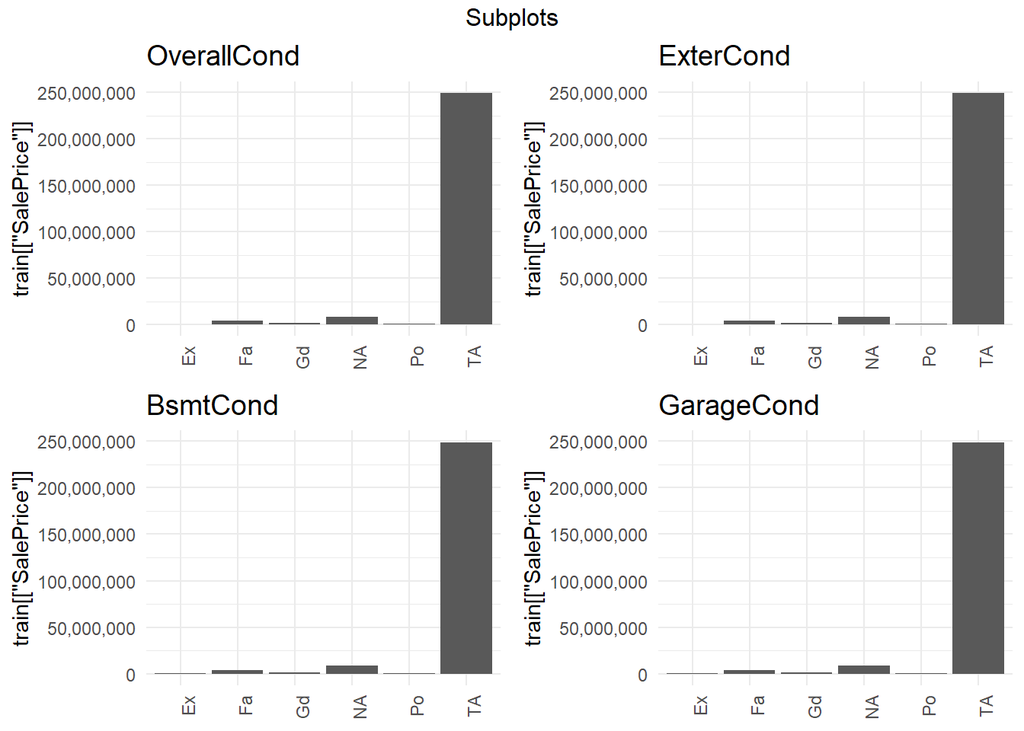

```r
labels <- c("OverallCond", "ExterCond", "BsmtCond", "GarageCond")
cols <- 1

plots <- list()

for (i in labels) {
  if (cols < 5) {
    plt <- ggplot(train, aes(x = train[[i]], y = train[["SalePrice"]])) +
      geom_bar(stat = "identity") +
      labs(x = NULL) +
      ggtitle(i) +
      theme_minimal() +
      theme(plot.title = element_text(size = 14),
            axis.text.x = element_text(angle = 90, hjust = 1)) +
      scale_y_continuous(labels = scales::comma)

    plots[[cols]] <- plt
  }
  cols <- cols + 1
}

grid.arrange(grobs = plots, nrow = 2, ncol = 2, top = "Subplots")
```

**Bathroom condition**

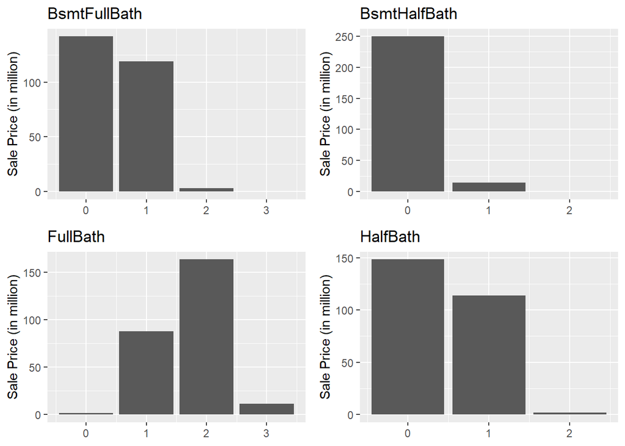

```r
# Custom function to format labels in millions
formatMillions <- function(x) {
  paste0(format(x / 1e6, big.mark = ","), "")
}

# Create individual bar plots
plot1 <- ggplot(train, aes(x = BsmtFullBath, y = SalePrice)) +
  geom_bar(stat = "identity") +
  labs(x = NULL, y = "Sale Price (in million)") +
  ggtitle("BsmtFullBath") +
  scale_y_continuous(labels = formatMillions)

plot2 <- ggplot(train, aes(x = BsmtHalfBath, y = SalePrice)) +
  geom_bar(stat = "identity") +
  labs(x = NULL, y = "Sale Price (in million)") +
  ggtitle("BsmtHalfBath") +
  scale_y_continuous(labels = formatMillions)

plot3 <- ggplot(train, aes(x = FullBath, y = SalePrice)) +
  geom_bar(stat = "identity") +
  labs(x = NULL, y = "Sale Price (in million)") +
  ggtitle("FullBath") +
  scale_y_continuous(labels = formatMillions)

plot4 <- ggplot(train, aes(x = HalfBath, y = SalePrice)) +
  geom_bar(stat = "identity") +
  labs(x = NULL, y = "Sale Price (in million)") +
  ggtitle("HalfBath") +
  scale_y_continuous(labels = formatMillions)

# Arrange the plots in a grid
grid.arrange(plot1, plot2, plot3, plot4, ncol = 2)
```

**Roof style and material**

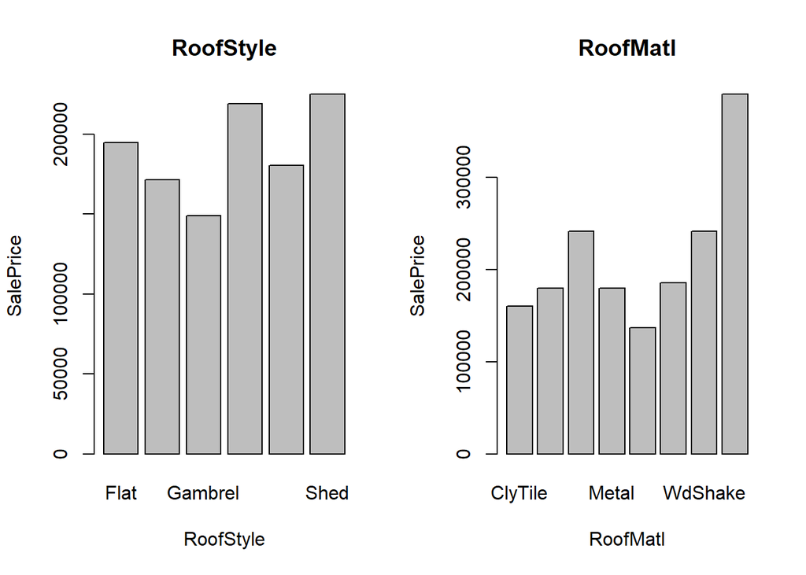

```r
par(mfrow = c(1, 2))
labels <- c("RoofStyle", "RoofMatl")

for (i in 1:length(labels)) {
  if (i <= 2) {
    barplot(tapply(train$SalePrice, train[, labels[i]], mean), xlab = labels[i], ylab = "SalePrice")
    title(main = labels[i])
  }
}
```

**Basement**

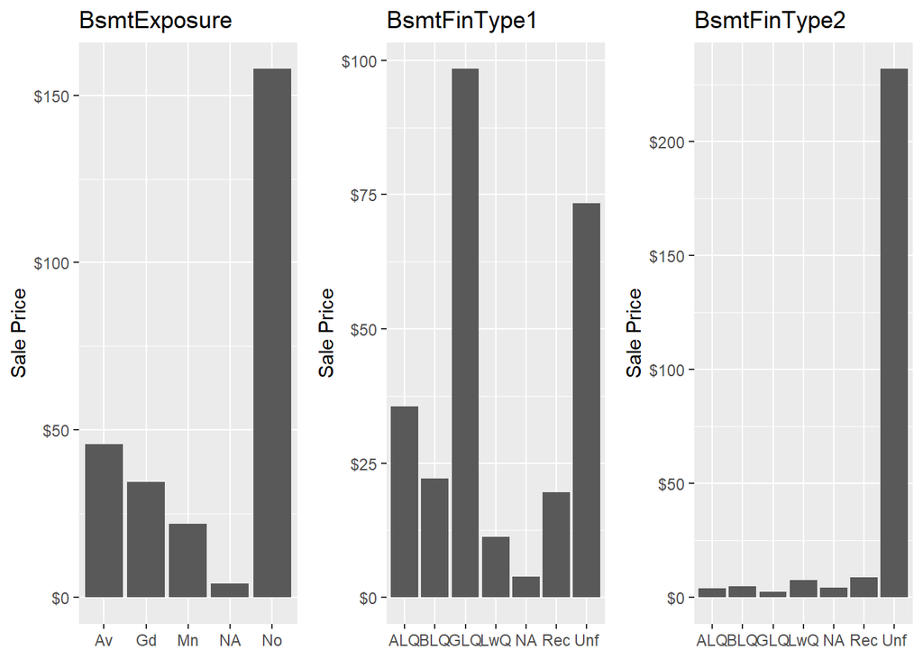

```r
# Create a list of labels
labels <- c("BsmtExposure", "BsmtFinType1", "BsmtFinType2")

# Create an empty list to store the plots
plots <- list()

# Loop through the labels and create bar plots
for (i in seq_along(labels)) {
  plot <- ggplot(train, aes_string(x = labels[i], y = "SalePrice")) +
    geom_bar(stat = "identity") +
    labs(x = NULL, y = "Sale Price") +
    ggtitle(labels[i]) +
    scale_y_continuous(labels = dollar_format(scale = 1e-6, prefix = "$"))

  plots[[i]] <- plot
}


# Arrange the plots in a grid
grid.arrange(grobs = plots, ncol = 3)
```

**Garage**

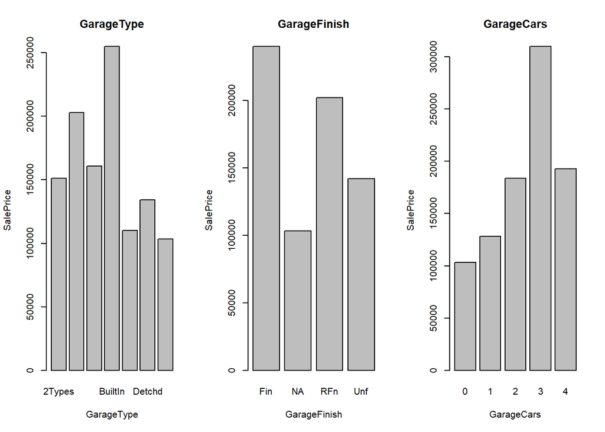

```r
par(mfrow = c(1, 3))
labels <- c("GarageType", "GarageFinish", "GarageCars")

for (i in 1:length(labels)) {
  if (i <= 3) {
    barplot(tapply(train$SalePrice, train[, labels[i]], mean), xlab = labels[i], ylab = "SalePrice")
    title(main = labels[i])
  }
}
```

**Month and Year of Sold**

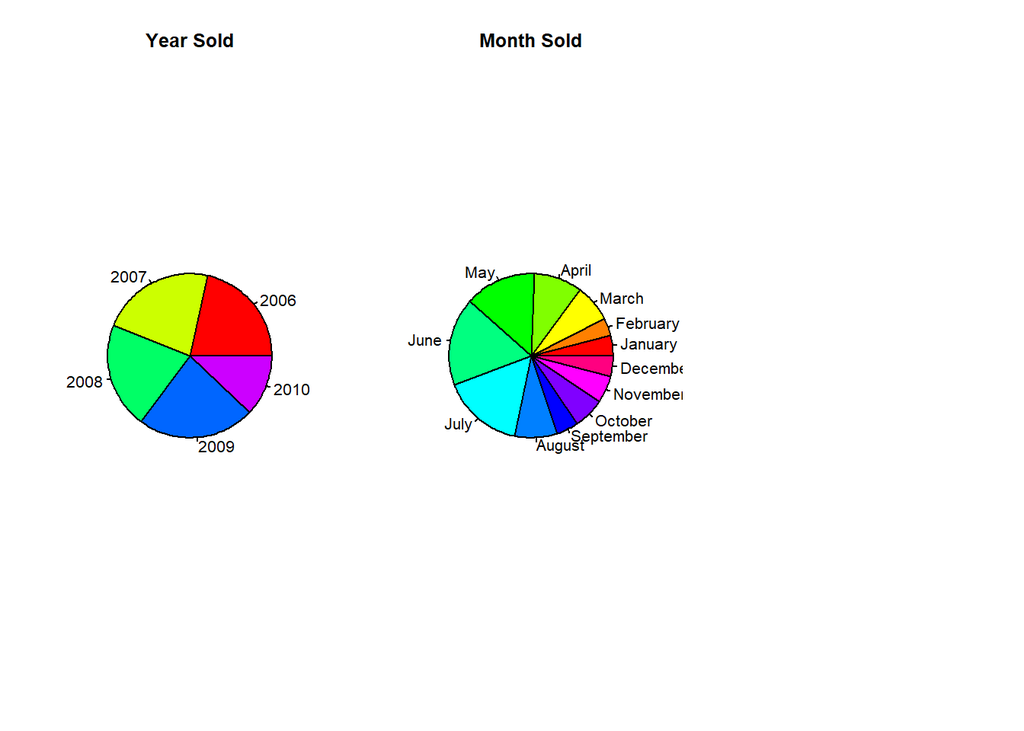

```r
par(mfrow = c(1, 3))
yearsold <- c(2006:2010)
monthsold <- c("January", "February", "March", "April", "May", "June", "July", "August", "September", "October", "November", "December")
years <- table(train$YrSold)
months <- table(train$MoSold)

pie(years, labels = yearsold, explode = c(0.1, 0.1, 0.1, 0.1, 0.1), col = rainbow(length(yearsold)), main = "Year Sold", cex.main = 1.2)
pie(months, labels = monthsold, explode = rep(0.1, 12), col = rainbow(length(monthsold)), main = "Month Sold", cex.main = 1.2)
```

**Note:** Maximum houses were sold in year 2009 and in month of June. We can also see a decline in sales from 2009 to 2010.

### 2.5.Transform Skewed Features

Plot histogram for each continuous feature to see if a transformation is necessary

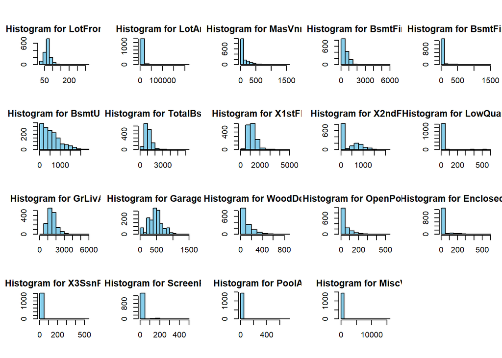

```r
par(mfrow = c(4, 5), mar = c(4, 4, 2, 1), oma = c(0, 0, 2, 0))
features <- colnames(train)

col <- 1
for (feature in features) {
  if (class(train[[feature]]) != "character") {
    if (!(feature %in% c("OverallQual", "OverallCond", "YearBuilt", "YearRemodAdd", "BsmtFullBath", "BsmtHalfBath", "FullBath", "HalfBath", "BedroomAbvGr", "KitchenAbvGr", "TotRmsAbvGrd", "Fireplaces", "GarageYrBlt", "GarageCars", "MoSold", "YrSold", "SalePrice"))) {
      if (col < 21) {
        hist(train[[feature]], main = paste("Histogram for", feature), xlab = "", ylab = "", col = "skyblue")
      }
      col <- col + 1
    }
  }
}
```

Box-Cox Power Transformation:

```r
train$LotFrontage <- train$LotFrontage^(1/3)
train$LotArea <- train$LotArea^(1/6)
train$MasVnrArea <- train$MasVnrArea^(1/1.5)
train$BsmtFinSF1 <- train$BsmtFinSF1^(1/1.4)
train$BsmtUnfSF <- train$BsmtUnfSF^(1/1.5)
train$TotalBsmtSF <- train$TotalBsmtSF^(1/1.4)
train$X1stFlrSF <- train$X1stFlrSF^(1/4)
train$GrLivArea <- train$GrLivArea^(1/4.5)
train$GarageArea <- train$GarageArea^(1/1.1)
train$WoodDeckSF <- train$WoodDeckSF^(1/1.2)
train$OpenPorchSF <- train$OpenPorchSF^(1/2.5)
```

### 2.6.Convert Categorical Features To Numeric

```r
features <- colnames(train)

for (feature in features) {
  if (class(train[[feature]]) == "character") {
    train[[feature]] <- as.integer(factor(train[[feature]]))
    test[[feature]] <- as.integer(factor(test[[feature]]))
  }
}
```

## Split Into Train And Test Set

Drop unnecessary features

```r
X <- train[, !colnames(train) %in% c("SalePrice")]

# Create the target variable
y <- train$SalePrice
```

Set the seed for reproducibility

```r
set.seed(42)
```

### Split the data into training and test sets

```r
train_indices <- sample(1:nrow(train), size = round(0.8 * nrow(train)), replace = FALSE)
X_train <- X[train_indices, ]
y_train <- y[train_indices]

X_test <- X[-train_indices, ]
y_test <- y[-train_indices]
```

### Standardize Features

Fit the scaler on the training data

```r
scaler <- scale(X_train)

# Apply the scaler to the training data
X_train_scaled <- scaler

# Apply the scaler to the test data
X_test_scaled <- scale(X_test, center = attr(scaler, "scaled:center"), scale = attr(scaler, "scaled:scale"))
```

Calculate the mean and standard deviation from the training set:

```r
scale_params <- apply(X_train, 2, mean)
scale_sd <- apply(X_train, 2, sd)

# Scale the training set
X_train_scaled <- scale(X_train, center = scale_params, scale = scale_sd)

# Scale the test set using the scaling parameters from the training set
X_test_scaled <- scale(X_test, center = scale_params, scale = scale_sd)
```

# MODELS

Let’s build initial functions for the models:

```r
# build finction for loss function
rmse_cv <- function(model) {
  rmse <- sqrt(-mean(cross_val_score(model, X, y, scoring = "neg_mean_squared_error", cv = 5)))
  return(round(rmse, 4))
}

evaluation <- function(y, predictions) {
  mae <- mean(abs(y - predictions))
  mse <- mean((y - predictions)^2)
  rmse <- sqrt(mse)
  r_squared <- 1 - (sum((y - predictions)^2) / sum((y - mean(y))^2))

  return(list(mae = round(mae, 4), mse = round(mse, 4), rmse = round(rmse, 4), r_squared = round(r_squared, 4)))
}

models <- data.frame(Model = character(),
                     MAE = numeric(),
                     MSE = numeric(),
                     RMSE = numeric(),
                     R2_Score = numeric(),
                     RMSE_CV = numeric(),
                     stringsAsFactors = FALSE)
```

## 1. Linear Regression

Well, firstly create linear regression model

```r
## Create a linear regression model
lin_reg <- lm(y_train ~ ., data = X_train)

## Make predictions on the test set
ln_predictions <- predict(lin_reg, newdata = X_test)

## Evaluate the model
mae <- mean(abs(ln_predictions - y_test))
mse <- mean((ln_predictions - y_test)^2)
rmse <- sqrt(mse)
r_squared <- summary(lin_reg)$r.squared

### Print the evaluation metrics
print(paste("MAE:", mae))
```

```
## [1] "MAE: 20276.1649935041"
```

```r
print(paste("MSE:", mse))
```

```
## [1] "MSE: 1174531451.46711"
```

```r
print(paste("RMSE:", rmse))
```

```
## [1] "RMSE: 34271.4378377551"
```

```r
print(paste("R2 Score:", r_squared))
```

```
## [1] "R2 Score: 0.855246479023401"
```

```r
## Perform cross-validation and calculate RMSE
rmse_cross_val <- sqrt(mean((predict(lin_reg, newdata = X_train) - y_train)^2))

### Print the cross-validated RMSE
print(paste("RMSE Cross-Validation:", rmse_cross_val))
```

```
## [1] "RMSE Cross-Validation: 29897.7985479486"
```

```r
## Create a data frame to store the model results
new_row <- data.frame(
  Model = "LinearRegression",
  MAE = mae,
  MSE = mse,
  RMSE = rmse,
  `R2 Score` = r_squared,
  `RMSE_CV` = rmse_cross_val,
  stringsAsFactors = FALSE  # Add this line to prevent factors
)

## Match the column names
colnames(new_row) <- colnames(models)

## Append the new row to the existing data frame (models)
models <- rbind(models, new_row)
```

## 2. Decision Tree

```r
## Train the decision tree model
d_tree <- rpart(y_train ~ ., data = X_train)

## Make predictions on the test set
predictions <- predict(d_tree, newdata = X_test)


## Evaluate the model
mae <- mean(abs(predictions - y_test))
mse <- mean((predictions - y_test)^2)
rmse <- sqrt(mse)
r_squared <- cor(predictions, y_test)^2

## Print the MAE
cat("MAE:", mae, "\n")
```

```
## MAE: 28836.32
```

```r
## Print the MSE
cat("MSE:", mse, "\n")
```

```
## MSE: 1722934536
```

```r
## Print the RMSE
cat("RMSE:", rmse, "\n")
```

```
## RMSE: 41508.25
```

```r
## Print the R2 Score
cat("R2 Score:", r_squared, "\n")
```

```
## R2 Score: 0.7578854
```

```r
## Perform cross-validation
cv_results <- rpart::rpart.control(cp = 0.01)  # Set the complexity parameter
cv_model <- rpart(y_train ~ ., data = X_train, control = cv_results)
cv_predictions <- predict(cv_model, newdata = X_train)

rmse_cross_val <- sqrt(mean((cv_predictions - y_train)^2))

## Print the RMSE Cross-Validation
cat("RMSE_CV:", round(rmse_cross_val, 2), "\n")
```

```
## RMSE_CV: 38219.59
```

```r
## Create a new row for the model's results
new_row <- data.frame(
  Model = "DecisionTree",
  MAE = mae,
  MSE = mse,
  RMSE = rmse,
  `R2 Score` = r_squared,
  `RMSE_CV` = rmse_cross_val
)

## Match the column names
colnames(new_row) <- colnames(models)

## Append the new row to the existing models dataframe
models <- rbind(models, new_row)
```

## 3. Random Forest

```r
# Define the cross-validation control
ctrl <- trainControl(method = "cv", number = 5)

# Fit the Random Forest model with cross-validation
random_forest <- train(x = X_train, y = y_train, method = "rf", ntree = 150, trControl = ctrl)

# Make predictions on the test set
predictions <- predict(random_forest, X_test)

# Evaluate the model
evaluation <- evaluation(y_test, predictions)

# Print the evaluation metrics
print(paste("MAE:", round(evaluation$mae, 4)))
```

```
## [1] "MAE: 16498.3851"
```

```r
print(paste("MSE:", round(evaluation$mse, 4)))
```

```
## [1] "MSE: 691707449.0365"
```

```r
print(paste("RMSE:", round(evaluation$rmse, 4)))
```

```
## [1] "RMSE: 26300.3317"
```

```r
print(paste("R2 Score:", round(evaluation$r_squared, 4)))
```

```
## [1] "R2 Score: 0.8985"
```

```r
# Calculate RMSE using cross-validation
rmse_cross_val <- sqrt(random_forest$results$RMSE)
print(paste("RMSE_CV:", round(rmse_cross_val, 4)))
```

```
## [1] "RMSE_CV: 186.7425" "RMSE_CV: 173.3396" "RMSE_CV: 174.2896"
```

```r
# Create a new row for the models dataframe
new_row <- data.frame(Model = "RandomForest",
                      MAE = evaluation$mae,
                      MSE = evaluation$mse,
                      RMSE = evaluation$rmse,
                      R2_Score = evaluation$r_squared,
                      RMSE_CV = rmse_cross_val)

# Append the new row to the models dataframe
models <- rbind(models, new_row)
```

## 4. Gradient Boosting Model

Codes for building model:

```r
# Gradient Bossting

g_boost <- gbm(y_train ~ ., data = X_train, n.trees = 100, interaction.depth = 3,distribution = "gaussian")

predictions <- predict(g_boost, newdata = X_test, n.trees = 100)

mae <- mean(abs(predictions - y_test))
mse <- mean((predictions - y_test)^2)
rmse <- sqrt(mse)
r_squared <- 1 - (sum((y_test - predictions)^2) / sum((y_test - mean(y_test))^2))

print(paste("MAE:", mae))
```

```
## [1] "MAE: 17574.4049657314"
```

```r
print(paste("MSE:", mse))
```

```
## [1] "MSE: 922715124.479919"
```

```r
print(paste("RMSE:", rmse))
```

```
## [1] "RMSE: 30376.2263041333"
```

```r
print(paste("R2 Score:", r_squared))
```

```
## [1] "R2 Score: 0.864634852963567"
```

```r
rmse_cross_val <- sqrt(crossprod(y_train - predict(g_boost, newdata = X_train, n.trees = 100))/(length(y_train) - 1))

print(paste("RMSE_CV:", rmse_cross_val))
```

```
## [1] "RMSE_CV: 21511.8121448758"
```

```r
new_row <- data.frame(Model = "GradientBoosting",
                      MAE = mae,
                      MSE = mse,
                      RMSE = rmse,
                      R2_Score = r_squared,
                      RMSE_CV = rmse_cross_val)

models <- rbind(models, new_row)
```

## 5. Extreme Gradient Boosting (XGBoost)

```r
# Convert the data to DMatrix format
dtrain <- xgb.DMatrix(data = as.matrix(X_train), label = y_train)
dtest <- xgb.DMatrix(data = as.matrix(X_test))

# Set the parameters for the XGBoost model
params <- list(
  objective = "reg:squarederror",
  eval_metric = "rmse"
)

# Train the XGBoost model
Xg_boost <- xgb.train(params = params, data = dtrain, nrounds = 100)

# Predict on the test set
predictions <- predict(Xg_boost, newdata = dtest)

# Calculate evaluation metrics
mae <- mean(abs(predictions - y_test))
mse <- mean((predictions - y_test)^2)
rmse <- sqrt(mse)
r_squared <- 1 - mse / var(y_test)

cat("MAE:", mae, "\n")
```

```
## MAE: 17603.54
```

```r
cat("MSE:", mse, "\n")
```

```
## MSE: 1026421853
```

```r
cat("RMSE:", rmse, "\n")
```

```
## RMSE: 32037.82
```

```r
cat("R2 Score:", r_squared, "\n")
```

```
## R2 Score: 0.8499364
```

```r
# Perform cross-validation to calculate RMSE
cv_result <- xgb.cv(params = params, data = dtrain, nfold = 5, nrounds = 100)
rmse_cross_val <- min(cv_result$evaluation_log$test_rmse_mean)

cat("RMSE Cross-Validation:", rmse_cross_val, "\n")
```

```
## RMSE Cross-Validation: 28955.46
```

```r
# Create a new row for the model results
new_row <- data.frame(Model = "XGradientBoosting",
                      MAE = mae,
                      MSE = mse,
                      RMSE = rmse,
                      R2_Score = r_squared,
                      RMSE_CV = rmse_cross_val)

# Append the new row to the models data frame
models <- rbind(models, new_row)
```

## 6. Support Vector Regression (SVR)

```r
# Fit the SVR model
svr <- svm(X_train, y_train, kernel = "radial", cost = 100000)

# Predict on the test set
predictions <- predict(svr, X_test)

# Calculate evaluation metrics
mae <- mean(abs(predictions - y_test))
mse <- mean((predictions - y_test)^2)

rmse <- sqrt(mse)
r_squared <- 1 - mse / var(y_test)

cat("MAE:", mae, "\n")
```

```
## MAE: 20515.66
```

```r
cat("MSE:", mse, "\n")
```

```
## MSE: 2010782287
```

```r
cat("RMSE:", rmse, "\n")
```

```
## RMSE: 44841.75
```

```r
cat("R2 Score:", r_squared, "\n")
```

```
## R2 Score: 0.7060223
```

```r
# Perform cross-validation to calculate RMSE
set.seed(42)
folds <- 5
cv_results <- vector("double", folds)

# Split the data into folds and perform cross-validation
for (i in 1:folds) {
  fold_indices <- seq(from = 1, to = nrow(X), length.out = folds + 1)
  fold_indices <- fold_indices[i:(i+1)]
  train_indices <- setdiff(1:nrow(X), fold_indices)

  fold_X_train <- X[train_indices, ]
  fold_y_train <- y[train_indices]
  fold_X_test <- X[fold_indices, ]
  fold_y_test <- y[fold_indices]

  fold_svr <- svm(fold_X_train, fold_y_train, kernel = "radial", cost = 100000)
  fold_predictions <- predict(fold_svr, fold_X_test)
  cv_results[i] <- sqrt(mean((fold_predictions - fold_y_test)^2))
}

cv_rmse <- mean(cv_results)

cat("RMSE Cross-Validation:", cv_rmse, "\n")
```

```
## RMSE Cross-Validation: 7096.218
```

```r
# Create a new row for the model results
new_row <- data.frame(Model = "SVR",
                      MAE = mae,
                      MSE = mse,
                      RMSE = rmse,
                      R2_Score = r_squared,
                      RMSE_CV = cv_rmse)

# Append the new row to the models data frame
models <- rbind(models, new_row)
```

# Comparison of the results of the models

```r
comparison_models <- models[order(models$RMSE), ]
comparison_models
```

```
##               Model      MAE        MSE     RMSE  R2_Score    RMSE_CV
## 3      RandomForest 16498.39  691707449 26300.33 0.8985000   186.7425
## 4      RandomForest 16498.39  691707449 26300.33 0.8985000   173.3396
## 5      RandomForest 16498.39  691707449 26300.33 0.8985000   174.2896
## 6  GradientBoosting 17574.40  922715124 30376.23 0.8646349 21511.8121
## 7 XGradientBoosting 17603.54 1026421853 32037.82 0.8499364 28955.4576
## 1  LinearRegression 20276.16 1174531451 34271.44 0.8552465 29897.7985
## 2      DecisionTree 28836.32 1722934536 41508.25 0.7578854 38219.5923
## 8               SVR 20515.66 2010782287 44841.75 0.7060223  7096.2183
```

# Conclusion

After evaluating the R2, MAE, and RMSE scores of various ML models, it was discovered that Random Forest achieved the highest performance on the chosen dataset, with GradientBoost securing the second position.